# Data Analyst NanoDegree Project 1

## Investigate Dataset - Medical Appointment No Shows

- Introduction
- Data Wrangling
- Exploratory Data Analysis
- Conclusions

## Introduction

This dataset contains data on patient appointments. The features are patient details and the target is whether or not the patient will show up to their appointment.

The intent of this analysis is to find out the kind of relationship these features have with the target variable(if any). The result of this analysis is tentative and a further analysis can be done to build a classification Machine Learning model to help predict if a patient will show up in future.

```python
# Import Libraries

import pandas as pd
import numpy as np
import seaborn as sns
import matplotlib.pyplot as plt
import datetime as dt
from pandas.api.types import CategoricalDtype

# Show visuals
%matplotlib inline

# Set background of graphs to darkgrid
sns.set_style("darkgrid")
```

## Data Wrangling

```python
# Read dataset

df = pd.read_csv('KaggleV2-May-2016.csv')
```

### General Data Overview

```python
# View first 5 rows of dataset
df.head()
```

|  | PatientId | AppointmentID | Gender | ScheduledDay | AppointmentDay | Age | Neighbourhood | Scholarship | Hipertension | Diabetes | Alcoholism | Handcap | SMS_received | No-show |
| --- | --- | --- | --- | --- | --- | --- | --- | --- | --- | --- | --- | --- | --- | --- |
| 0 | 2.987250e+13 | 5642903 | F | 2016-04-29T18:38:08Z | 2016-04-29T00:00:00Z | 62 | JARDIM DA PENHA | 0 | 1 | 0 | 0 | 0 | 0 | No |
| 1 | 5.589978e+14 | 5642503 | M | 2016-04-29T16:08:27Z | 2016-04-29T00:00:00Z | 56 | JARDIM DA PENHA | 0 | 0 | 0 | 0 | 0 | 0 | No |
| 2 | 4.262962e+12 | 5642549 | F | 2016-04-29T16:19:04Z | 2016-04-29T00:00:00Z | 62 | MATA DA PRAIA | 0 | 0 | 0 | 0 | 0 | 0 | No |
| 3 | 8.679512e+11 | 5642828 | F | 2016-04-29T17:29:31Z | 2016-04-29T00:00:00Z | 8 | PONTAL DE CAMBURI | 0 | 0 | 0 | 0 | 0 | 0 | No |
| 4 | 8.841186e+12 | 5642494 | F | 2016-04-29T16:07:23Z | 2016-04-29T00:00:00Z | 56 | JARDIM DA PENHA | 0 | 1 | 1 | 0 | 0 | 0 | No |

```python
# Obtain dataset shape

df.shape
```

```
(110527, 14)
```

**Observation:**

- Dataset has 110527 rows and 14 columns

```python
df.info()
```

```
<class 'pandas.core.frame.DataFrame'>
RangeIndex: 110527 entries, 0 to 110526
Data columns (total 14 columns):
 #   Column          Non-Null Count   Dtype
---  ------          --------------   -----
 0   PatientId       110527 non-null  float64
 1   AppointmentID   110527 non-null  int64
 2   Gender          110527 non-null  object
 3   ScheduledDay    110527 non-null  object
 4   AppointmentDay  110527 non-null  object
 5   Age             110527 non-null  int64
 6   Neighbourhood   110527 non-null  object
 7   Scholarship     110527 non-null  int64
 8   Hipertension    110527 non-null  int64
 9   Diabetes        110527 non-null  int64
 10  Alcoholism      110527 non-null  int64
 11  Handcap         110527 non-null  int64
 12  SMS_received    110527 non-null  int64
 13  No-show         110527 non-null  object
dtypes: float64(1), int64(8), object(5)
memory usage: 11.8+ MB
```

```python
# Get statistics of our dataset
df.describe()
```

|  | PatientId | AppointmentID | Age | Scholarship | Hipertension | Diabetes | Alcoholism | Handcap | SMS_received |
| --- | --- | --- | --- | --- | --- | --- | --- | --- | --- |
| count | 1.105270e+05 | 1.105270e+05 | 110527.000000 | 110527.000000 | 110527.000000 | 110527.000000 | 110527.000000 | 110527.000000 | 110527.000000 |
| mean | 1.474963e+14 | 5.675305e+06 | 37.088874 | 0.098266 | 0.197246 | 0.071865 | 0.030400 | 0.022248 | 0.321026 |
| std | 2.560949e+14 | 7.129575e+04 | 23.110205 | 0.297675 | 0.397921 | 0.258265 | 0.171686 | 0.161543 | 0.466873 |
| min | 3.921784e+04 | 5.030230e+06 | -1.000000 | 0.000000 | 0.000000 | 0.000000 | 0.000000 | 0.000000 | 0.000000 |
| 25% | 4.172614e+12 | 5.640286e+06 | 18.000000 | 0.000000 | 0.000000 | 0.000000 | 0.000000 | 0.000000 | 0.000000 |
| 50% | 3.173184e+13 | 5.680573e+06 | 37.000000 | 0.000000 | 0.000000 | 0.000000 | 0.000000 | 0.000000 | 0.000000 |
| 75% | 9.439172e+13 | 5.725524e+06 | 55.000000 | 0.000000 | 0.000000 | 0.000000 | 0.000000 | 0.000000 | 1.000000 |
| max | 9.999816e+14 | 5.790484e+06 | 115.000000 | 1.000000 | 1.000000 | 1.000000 | 1.000000 | 4.000000 | 1.000000 |

**Observation:**

- Minimum age is -1 and is an error in the dataset wich has to be dropped. To see how many entries have this erroneous value,

```python
# Drop entry where Age = -1
df[df.Age == -1].shape[0]
```

```
1
```

```python
# Drop entry where age = -1
df = df[df.Age!=-1]
```

**Observation:**

- Maximum age is 115. To see the patients above 100 yrs,

```python
# Check to see the entries where patients are above 100
df[df.Age >= 100]
```

|  | PatientId | AppointmentID | Gender | ScheduledDay | AppointmentDay | Age | Neighbourhood | Scholarship | Hipertension | Diabetes | Alcoholism | Handcap | SMS_received | No-show |
| --- | --- | --- | --- | --- | --- | --- | --- | --- | --- | --- | --- | --- | --- | --- |
| 58014 | 9.762948e+14 | 5651757 | F | 2016-05-03T09:14:53Z | 2016-05-03T00:00:00Z | 102 | CONQUISTA | 0 | 0 | 0 | 0 | 0 | 0 | No |
| 63912 | 3.196321e+13 | 5700278 | F | 2016-05-16T09:17:44Z | 2016-05-19T00:00:00Z | 115 | ANDORINHAS | 0 | 0 | 0 | 0 | 1 | 0 | Yes |
| 63915 | 3.196321e+13 | 5700279 | F | 2016-05-16T09:17:44Z | 2016-05-19T00:00:00Z | 115 | ANDORINHAS | 0 | 0 | 0 | 0 | 1 | 0 | Yes |
| 68127 | 3.196321e+13 | 5562812 | F | 2016-04-08T14:29:17Z | 2016-05-16T00:00:00Z | 115 | ANDORINHAS | 0 | 0 | 0 | 0 | 1 | 0 | Yes |
| 76284 | 3.196321e+13 | 5744037 | F | 2016-05-30T09:44:51Z | 2016-05-30T00:00:00Z | 115 | ANDORINHAS | 0 | 0 | 0 | 0 | 1 | 0 | No |
| 79270 | 9.739430e+12 | 5747809 | M | 2016-05-30T16:21:56Z | 2016-05-31T00:00:00Z | 100 | TABUAZEIRO | 0 | 0 | 0 | 0 | 1 | 0 | No |
| 79272 | 9.739430e+12 | 5747808 | M | 2016-05-30T16:21:56Z | 2016-05-31T00:00:00Z | 100 | TABUAZEIRO | 0 | 0 | 0 | 0 | 1 | 0 | No |
| 90372 | 2.342836e+11 | 5751563 | F | 2016-05-31T10:19:49Z | 2016-06-02T00:00:00Z | 102 | MARIA ORTIZ | 0 | 0 | 0 | 0 | 0 | 0 | No |
| 92084 | 5.578313e+13 | 5670914 | F | 2016-05-06T14:55:36Z | 2016-06-03T00:00:00Z | 100 | ANTÔNIO HONÓRIO | 0 | 0 | 0 | 0 | 0 | 1 | No |
| 97666 | 7.482346e+14 | 5717451 | F | 2016-05-19T07:57:56Z | 2016-06-03T00:00:00Z | 115 | SÃO JOSÉ | 0 | 1 | 0 | 0 | 0 | 1 | No |
| 108506 | 3.939642e+11 | 5721152 | F | 2016-05-19T15:32:09Z | 2016-06-01T00:00:00Z | 100 | MARUÍPE | 0 | 0 | 0 | 0 | 0 | 0 | No |

```python
# Check entries where patientID where age = 115

df[df.Age == 115]
```

|  | PatientId | AppointmentID | Gender | ScheduledDay | AppointmentDay | Age | Neighbourhood | Scholarship | Hipertension | Diabetes | Alcoholism | Handcap | SMS_received | No-show |
| --- | --- | --- | --- | --- | --- | --- | --- | --- | --- | --- | --- | --- | --- | --- |
| 63912 | 3.196321e+13 | 5700278 | F | 2016-05-16T09:17:44Z | 2016-05-19T00:00:00Z | 115 | ANDORINHAS | 0 | 0 | 0 | 0 | 1 | 0 | Yes |
| 63915 | 3.196321e+13 | 5700279 | F | 2016-05-16T09:17:44Z | 2016-05-19T00:00:00Z | 115 | ANDORINHAS | 0 | 0 | 0 | 0 | 1 | 0 | Yes |
| 68127 | 3.196321e+13 | 5562812 | F | 2016-04-08T14:29:17Z | 2016-05-16T00:00:00Z | 115 | ANDORINHAS | 0 | 0 | 0 | 0 | 1 | 0 | Yes |
| 76284 | 3.196321e+13 | 5744037 | F | 2016-05-30T09:44:51Z | 2016-05-30T00:00:00Z | 115 | ANDORINHAS | 0 | 0 | 0 | 0 | 1 | 0 | No |
| 97666 | 7.482346e+14 | 5717451 | F | 2016-05-19T07:57:56Z | 2016-06-03T00:00:00Z | 115 | SÃO JOSÉ | 0 | 1 | 0 | 0 | 0 | 1 | No |

```python
# Check patient ID where age = 115

df[df.Age == 115].PatientId.unique()
```

```
array([3.19632116e+13, 7.48234579e+14])
```

**Observation:**

- We have 2 patients whose age is 115.

```python
# View statistics of object columns
df.describe(include='object')
```

|  | Gender | ScheduledDay | AppointmentDay | Neighbourhood | No-show |
| --- | --- | --- | --- | --- | --- |
| count | 110526 | 110526 | 110526 | 110526 | 110526 |
| unique | 2 | 103548 | 27 | 81 | 2 |
| top | F | 2016-05-06T07:09:54Z | 2016-06-06T00:00:00Z | JARDIM CAMBURI | No |
| freq | 71839 | 24 | 4691 | 7717 | 88207 |

From the understanding of this dataset, the intent is to figure out the probability of a patient showing up for their appointment(No-Show). Looking at the snippet above, PatientID and AppointmentID do not have any impact on our target variable and will be dropped. ScheduledDay and AppointmentDay should also be formatted as dates

However, before droping the unique identifiers for the records, let's check for duplicates.

**Action:**

- Check for duplicates
- Drop unwanted columns
- Change data type of ScheduledDay and AppointmentDay

```python
# Check for duplicates in dataframe
df.duplicated().sum()
```

```
0
```

**Observation:**

- There are no duplicates so we can proceed to dropping the columns not needed

### Drop Unwanted Columns

```python
# Drop PatientID and AppointmentID columns

df = df.drop(['PatientId', 'AppointmentID'], axis=1)
df.head()
```

|  | Gender | ScheduledDay | AppointmentDay | Age | Neighbourhood | Scholarship | Hipertension | Diabetes | Alcoholism | Handcap | SMS_received | No-show |
| --- | --- | --- | --- | --- | --- | --- | --- | --- | --- | --- | --- | --- |
| 0 | F | 2016-04-29T18:38:08Z | 2016-04-29T00:00:00Z | 62 | JARDIM DA PENHA | 0 | 1 | 0 | 0 | 0 | 0 | No |
| 1 | M | 2016-04-29T16:08:27Z | 2016-04-29T00:00:00Z | 56 | JARDIM DA PENHA | 0 | 0 | 0 | 0 | 0 | 0 | No |
| 2 | F | 2016-04-29T16:19:04Z | 2016-04-29T00:00:00Z | 62 | MATA DA PRAIA | 0 | 0 | 0 | 0 | 0 | 0 | No |
| 3 | F | 2016-04-29T17:29:31Z | 2016-04-29T00:00:00Z | 8 | PONTAL DE CAMBURI | 0 | 0 | 0 | 0 | 0 | 0 | No |
| 4 | F | 2016-04-29T16:07:23Z | 2016-04-29T00:00:00Z | 56 | JARDIM DA PENHA | 0 | 1 | 1 | 0 | 0 | 0 | No |

```python
# Obtain dataset shape - should have 12 columns now

df.shape
```

```
(110526, 12)
```

### Fix Data Types

**To do:**

- ScheduledDay and AppointmentDay are datetime columns so the datatype should be changed from object to datetime.
- To accurately view data statistics on 'Scholarship', 'Hipertension', 'Diabetes', 'Alcoholism', 'Handcap', 'SMS_received', I'll change data-type to object.

> **Note:** It's important to note that these will have to be properly encoded when extending analysis to prediction.

```python
# Get specifics on data

df.info()
```

```
<class 'pandas.core.frame.DataFrame'>
Int64Index: 110526 entries, 0 to 110526
Data columns (total 12 columns):
 #   Column          Non-Null Count   Dtype
---  ------          --------------   -----
 0   Gender          110526 non-null  object
 1   ScheduledDay    110526 non-null  object
 2   AppointmentDay  110526 non-null  object
 3   Age             110526 non-null  int64
 4   Neighbourhood   110526 non-null  object
 5   Scholarship     110526 non-null  int64
 6   Hipertension    110526 non-null  int64
 7   Diabetes        110526 non-null  int64
 8   Alcoholism      110526 non-null  int64
 9   Handcap         110526 non-null  int64
 10  SMS_received    110526 non-null  int64
 11  No-show         110526 non-null  object
dtypes: int64(7), object(5)
memory usage: 11.0+ MB
```

```python
# View column names
df.columns
```

```
Index(['Gender', 'ScheduledDay', 'AppointmentDay', 'Age', 'Neighbourhood',
       'Scholarship', 'Hipertension', 'Diabetes', 'Alcoholism', 'Handcap',
       'SMS_received', 'No-show'],
      dtype='object')
```

```python
# Change 'ScheduledDay' and 'AppointmentDay' from object to datetime64[ns]
df.ScheduledDay = pd.to_datetime(df.ScheduledDay)
df.AppointmentDay = pd.to_datetime(df.AppointmentDay)
```

```python
# Change dtype of aforementioned int columns
cols = ['Scholarship', 'Hipertension', 'Diabetes', 'Alcoholism', 'Handcap', 'SMS_received']
df[cols] = df[cols].astype(str)
```

### Replace Column Values

The No-show column has 2 values. 'No' if patient showed up and 'Yes' if they missed their appointment. To avoid any mix up in graph interpretation, I'll rename 'No' to 'Attended' and 'Yes' to 'Missed'

```python
# Check for value counts
df['No-show'].value_counts()
```

```
No     88207
Yes    22319
Name: No-show, dtype: int64
```

```python
# Replace values
df['No-show'] = df['No-show'].replace(['Yes', 'No'],['Missed', 'Attended'])
```

```python
# Check for value counts
df['No-show'].value_counts()
```

```
Attended    88207
Missed      22319
Name: No-show, dtype: int64
```

### Derived Columns

For better analysis of the Dataset, new columns need to be derived from existing columns. The new derived columns will be:

```
a. age_groups from Age column
b. day_of_week from AppointmentDay
c. wait_time in days from AppointmentDay and ScheduledDay
```

#### a. age_groups from Age column

Groupings derived from this [link](https://www.indexmundi.com/brazil/age_structure.html)

```python
bins = [0,14,24,54,64,115] #bins to get segmentations
labels = ['Child','Young Adult', 'Adult', 'Mature Adult', 'Elderly'] # grouping names
df['age_group'] = pd.cut(x=df.Age, bins=bins, labels=labels) # create new column with aforementioned labels
df.head()
```

|  | Gender | ScheduledDay | AppointmentDay | Age | Neighbourhood | Scholarship | Hipertension | Diabetes | Alcoholism | Handcap | SMS_received | No-show | age_group |
| --- | --- | --- | --- | --- | --- | --- | --- | --- | --- | --- | --- | --- | --- |
| 0 | F | 2016-04-29 18:38:08+00:00 | 2016-04-29 00:00:00+00:00 | 62 | JARDIM DA PENHA | 0 | 1 | 0 | 0 | 0 | 0 | Attended | Mature Adult |
| 1 | M | 2016-04-29 16:08:27+00:00 | 2016-04-29 00:00:00+00:00 | 56 | JARDIM DA PENHA | 0 | 0 | 0 | 0 | 0 | 0 | Attended | Mature Adult |
| 2 | F | 2016-04-29 16:19:04+00:00 | 2016-04-29 00:00:00+00:00 | 62 | MATA DA PRAIA | 0 | 0 | 0 | 0 | 0 | 0 | Attended | Mature Adult |
| 3 | F | 2016-04-29 17:29:31+00:00 | 2016-04-29 00:00:00+00:00 | 8 | PONTAL DE CAMBURI | 0 | 0 | 0 | 0 | 0 | 0 | Attended | Child |
| 4 | F | 2016-04-29 16:07:23+00:00 | 2016-04-29 00:00:00+00:00 | 56 | JARDIM DA PENHA | 0 | 1 | 1 | 0 | 0 | 0 | Attended | Mature Adult |

#### b. day_of_week from AppointmentDay

```python
# Get day of week from appointment day
df['day_of_week'] = df['AppointmentDay'].dt.day_name()
```

To ensure ordering of this column, we need to change it to a categorical column

```python
cats = [ 'Monday', 'Tuesday', 'Wednesday', 'Thursday', 'Friday', 'Saturday', 'Sunday']
cat_type = CategoricalDtype(categories=cats, ordered=True)
df['day_of_week']=df['day_of_week'].astype(cat_type)
```

#### c. wait_time in days from AppointmentDay and ScheduledDay

```python
#Difference in number of days betweeen when patient called to set up appointment and set date of appointment
df['wait_days'] =  (df.AppointmentDay - df.ScheduledDay).dt.days
df.head()
```

|  | Gender | ScheduledDay | AppointmentDay | Age | Neighbourhood | Scholarship | Hipertension | Diabetes | Alcoholism | Handcap | SMS_received | No-show | age_group | day_of_week | wait_days |
| --- | --- | --- | --- | --- | --- | --- | --- | --- | --- | --- | --- | --- | --- | --- | --- |
| 0 | F | 2016-04-29 18:38:08+00:00 | 2016-04-29 00:00:00+00:00 | 62 | JARDIM DA PENHA | 0 | 1 | 0 | 0 | 0 | 0 | Attended | Mature Adult | Friday | -1 |
| 1 | M | 2016-04-29 16:08:27+00:00 | 2016-04-29 00:00:00+00:00 | 56 | JARDIM DA PENHA | 0 | 0 | 0 | 0 | 0 | 0 | Attended | Mature Adult | Friday | -1 |
| 2 | F | 2016-04-29 16:19:04+00:00 | 2016-04-29 00:00:00+00:00 | 62 | MATA DA PRAIA | 0 | 0 | 0 | 0 | 0 | 0 | Attended | Mature Adult | Friday | -1 |
| 3 | F | 2016-04-29 17:29:31+00:00 | 2016-04-29 00:00:00+00:00 | 8 | PONTAL DE CAMBURI | 0 | 0 | 0 | 0 | 0 | 0 | Attended | Child | Friday | -1 |
| 4 | F | 2016-04-29 16:07:23+00:00 | 2016-04-29 00:00:00+00:00 | 56 | JARDIM DA PENHA | 0 | 1 | 1 | 0 | 0 | 0 | Attended | Mature Adult | Friday | -1 |

### View Data Stats

```python
# Get statistics on numeric columns

df.describe()
```

|  | Age | wait_days |
| --- | --- | --- |
| count | 110526.000000 | 110526.000000 |
| mean | 37.089219 | 9.183794 |
| std | 23.110026 | 15.255034 |
| min | 0.000000 | -7.000000 |
| 25% | 18.000000 | -1.000000 |
| 50% | 37.000000 | 3.000000 |
| 75% | 55.000000 | 14.000000 |
| max | 115.000000 | 178.000000 |

**Observation:**

- We have wait days < 0

**Action:**

- Eliminate dataset where wait days is less than 0 as this is an error(assigned to a new variable - to evaluate impact of waiting time on attendance)

```python
# See the size of dataset with wait time error
df[df.wait_days<0].shape
```

```
(38567, 15)
```

```python
# Create new dataset where wait days > 0
df_wait = df[df.wait_days>=0]
df_wait.describe()
```

|  | Age | wait_days |
| --- | --- | --- |
| count | 71959.000000 | 71959.000000 |
| mean | 38.502564 | 14.642018 |
| std | 22.925421 | 16.494334 |
| min | 0.000000 | 0.000000 |
| 25% | 19.000000 | 3.000000 |
| 50% | 39.000000 | 8.000000 |
| 75% | 57.000000 | 21.000000 |
| max | 115.000000 | 178.000000 |

### Define Functions to visualize dataset

Defining functions to visualize data will help eliminate repitittion of code. The functions defined will be to plot

```
a. Histogram to view distribution of continuous variables
b. Pie Chart to view percentage of categorical variable in our sample
c. Detailed bar chart to show what proportions of attendance we have in relation to other categorical variables
```

#### a. Histogram to view distribution of continuous variables

```python
# Define function

def cont_hist(df,col):
    # Select Column
    cont_var = df[col]

    # Get statistics
    minm = cont_var.min()
    maxm = cont_var.max()
    avg = cont_var.mean()

    print('Min {0}:{1}\nMax {0}:{2}\nAverage {0}:{3:.2f}\n'.format(col,minm,maxm,avg))

    # Plot Histogram
    cont_var.hist(figsize = (8,8))

    #Plot stat lines
    plt.axvline(x=minm, color='green', linestyle='dashed')
    plt.axvline(x=maxm, color='yellow', linestyle='dashed')
    plt.axvline(x=avg , color='red', linestyle='dashed')


    # Add title and axis labels
    plt.title('{} Distribution'.format(col))
    plt.xlabel('{}'.format(col))
    plt.ylabel('Number of Patients')
```

#### b. Pie Chart to view percentage of categorical variable in our sample

```python
# Define function

# with labels
def var_pie_label(col,labels):
    #Plot pie chart
    ax = df[col].value_counts().plot(kind='pie', autopct='%.2f%%', title = 'Percentage of {}'.format(col), labels=labels, figsize = (8,8))
    # Remove column label from chart
    ax.yaxis.set_visible(False)
    plt.show()

# without labels
def var_pie(col):
    #Plot pie chart
    ax = df[col].value_counts().plot(kind='pie', autopct='%.2f%%', title = 'Percentage of {}'.format(col), figsize = (8,8))
    # Remove column label from chart
    ax.yaxis.set_visible(False)
    plt.show()
```

#### c. Detailed bar chart to show what proportions of attendance we have in relation to other categorical variables

```python
# Define function

def var_proportion(data, labels, x_col):
        #calculate proportions
        counts = df.groupby(['No-show', x_col]).count()['ScheduledDay']
        totals = df.groupby('No-show').count()['ScheduledDay']
        attended = counts['Attended']/totals['Attended']
        missed = counts['Missed']/totals['Missed']

        #plot bar chart
        ind = np.arange(len(attended))  # the x locations for the groups
        width = 0.35
        locations = ind + width / 2  # xtick locations

        attended_bars = plt.bar(ind, attended, width, color='g', alpha=.7, label='Attended')
        missed_bars = plt.bar(ind+width, missed, width, color='r', alpha=.7, label='Missed')


        plt.xticks(locations, labels)

        # title and labels
        plt.ylabel('Attendance Proportion')
        plt.xlabel('{}'.format(x_col))
        plt.title('Proportion of Attendance against {}'.format(x_col))

        # legend
        plt.legend(numpoints=1)
```

## Exploratory Data Analysis

### Research Question 1: What are the statistic attributes of our categorical columns?

```python
# Get statistics on object columns

df.describe(include='object')
```

|  | Gender | Neighbourhood | Scholarship | Hipertension | Diabetes | Alcoholism | Handcap | SMS_received | No-show |
| --- | --- | --- | --- | --- | --- | --- | --- | --- | --- |
| count | 110526 | 110526 | 110526 | 110526 | 110526 | 110526 | 110526 | 110526 | 110526 |
| unique | 2 | 81 | 2 | 2 | 2 | 2 | 5 | 2 | 2 |
| top | F | JARDIM CAMBURI | 0 | 0 | 0 | 0 | 0 | 0 | Attended |
| freq | 71839 | 7717 | 99665 | 88725 | 102583 | 107166 | 108285 | 75044 | 88207 |

**Observation:**

- **Gender**: We have more female patients than males
- **Neighborhood**: We have 81 neighborhoods, with most patients coming from **JARDIM CAMBURI**
- **Scholarship**: Most patients do not have a scholarship
- **Hypertension**: Most patients do not have hypertension
- **Diabetes**: Most patients do not have a diabetes
- **Alcohol**: Most patients do not take alcohol
- **Handicap**: We have 5 different handicap categories; With 0 meaning no handicap, ,ost patients are not handicapped
- **SMS-Received**: Most patients did not reminders for their appointments via text
- **Day of Week**: Most appointments are set for Wednesday, and the dataset has appointments for 6 days of the week

### Research Question 2: From the dataset, what percentage of patients missed their appointments?

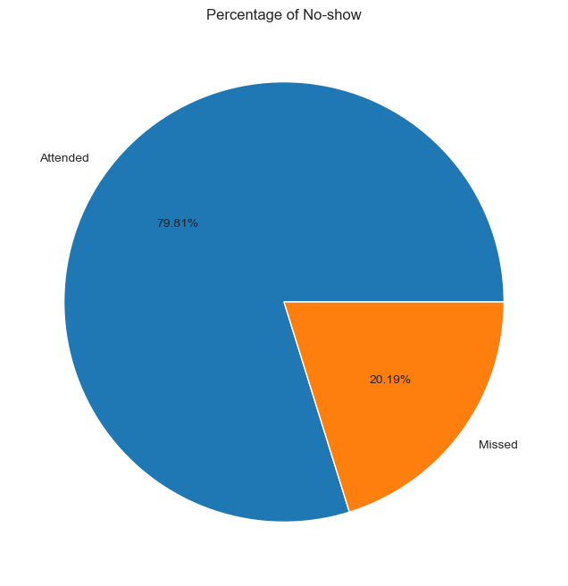

```python
# Use pie chart function
var_pie('No-show')
```

**Answer:**

- 20% of patients missed their appointments.

### Research Question 3: What is the age distribution of patients?

```
Min Age:0
Max Age:115
Average Age:37.09
```

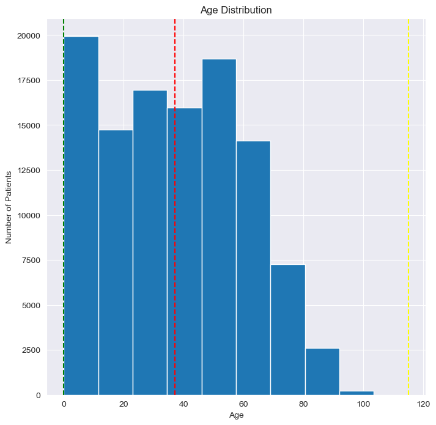

```python
# Use histogram function to view distribution
cont_hist(df, 'Age')
```

**Answer:**

- Age distribution is skewed to the right. The minimum age is 0, maximum age is 115 and the average age is approximately 37 years.

### Research Question 4: Does age have a relationship with probability of patients showing up?

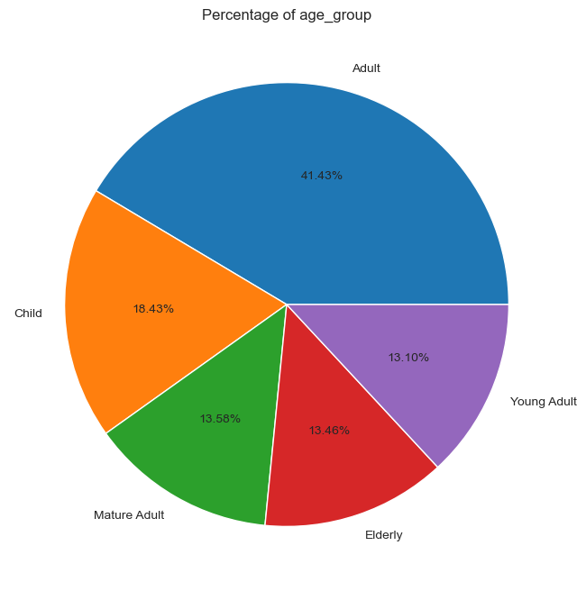

```python
#View distribution of age_group on dataset
var_pie('age_group')
```

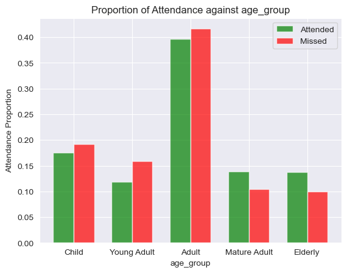

```python
#Use proportion function to see proportion of attendance against age_group
labels = ['Child', 'Young Adult', 'Adult', 'Mature Adult', 'Elderly']
x_col = 'age_group'
age_vs_attendance_proportions = var_proportion(df, labels, x_col)
```

**Answer:**

- Patients in the Child, Young Adult and Adult categories seem to have a higher missing rate. For Mature Adults and the Elderly, they're more likely to show up for appointments.

### Research Question 5: Do patients with Scholarship tend to show up more?

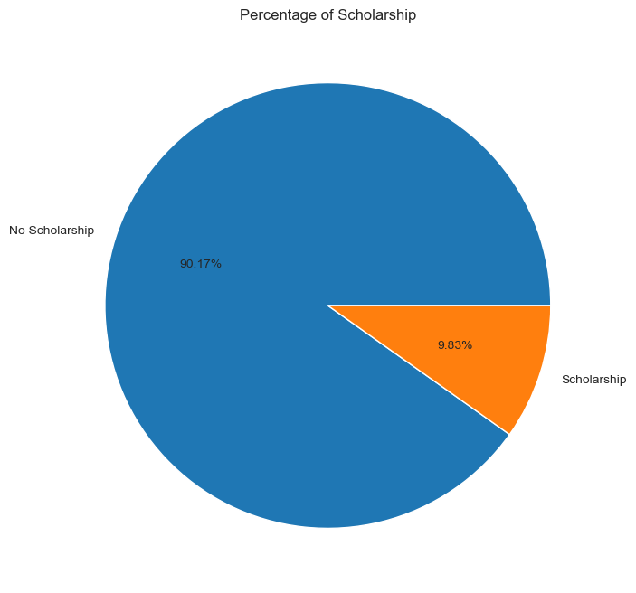

```python
#View distribution of scholarship on dataset
labels = ['No Scholarship', 'Scholarship']
var_pie_label('Scholarship', labels)
```

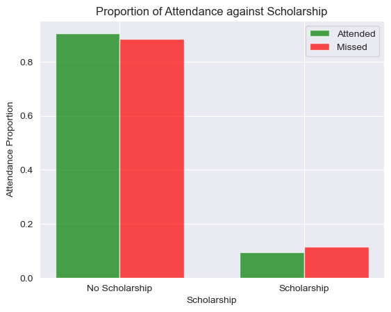

```python
#Use proportion function to see proportion of attendance against scholarship

labels = ['No Scholarship', 'Scholarship']
x_col = 'Scholarship'
scholarship_vs_attendance_proportions = var_proportion(df, labels, x_col)
```

### Research Question 6: Is a certain gender associated with a higher attendance rate?

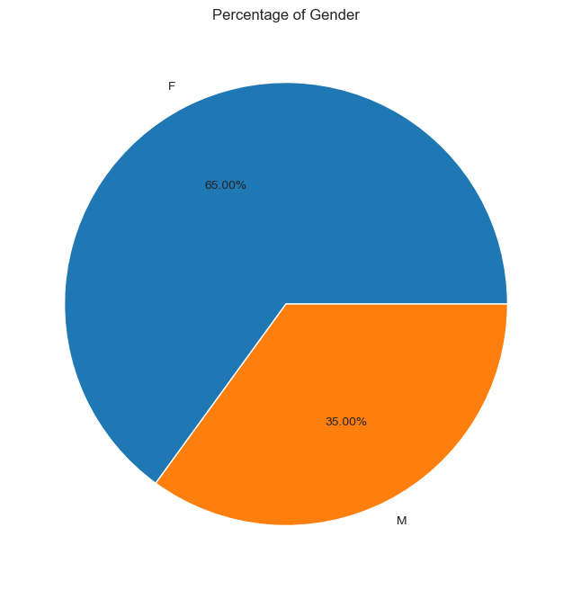

```python
# First identify distribution of gender with a pie chart
var_pie('Gender')
```

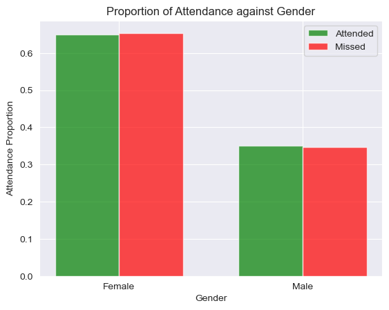

```python
#Use proportion function to see proportion of attendance against gender

labels = ['Female', 'Male']
x_col = 'Gender'
gender_vs_attendance_proportions = var_proportion(df, labels, x_col)
```

**Answer:**

- The sample has more females than males. When it comes to attendance, the proportions of thse who missed to those who attended does not have a large variance so there exists no relationship between gender and probability of attendandce.

### Research Question 7: Do patients that receive a text tend to show up more?

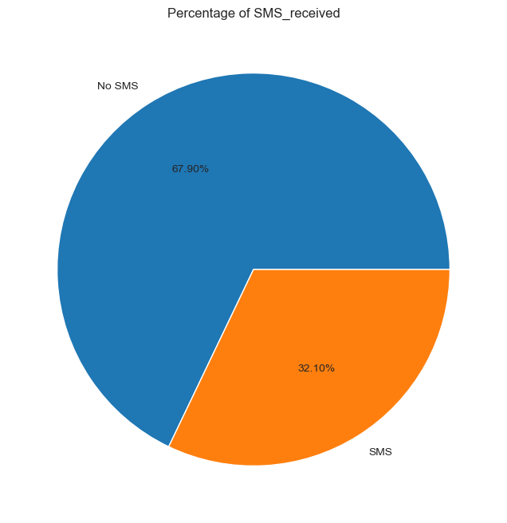

```python
# First identify distribution of SMS received with a pie chart
labels = ['No SMS', 'SMS']
var_pie_label('SMS_received', labels)
```

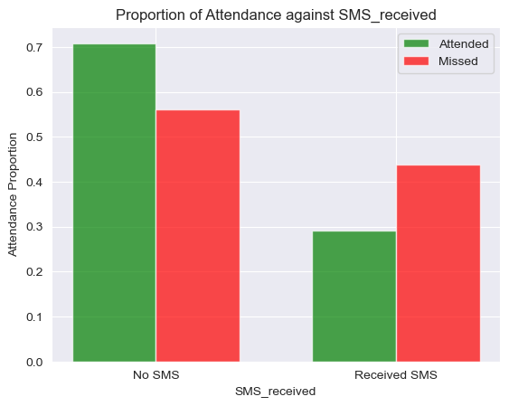

```python
#Use proportion function to see proportion of attendance against gender

labels = ['No SMS', 'Received SMS']
x_col = 'SMS_received'
text_vs_attendance_proportions = var_proportion(df, labels, x_col)
```

### Research Question 8: Is there any relationship between alcoholism of patients and their and showing up for appointments?

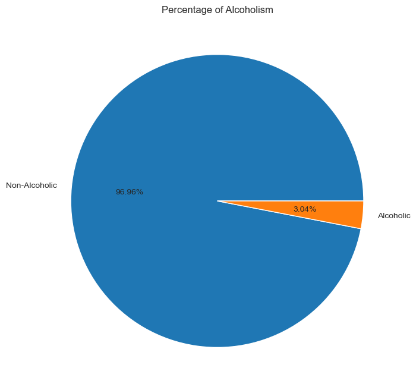

```python
# First identify distribution of Alcoholism with a pie chart

labels = ['Non-Alcoholic', 'Alcoholic']
var_pie_label('Alcoholism', labels)
```

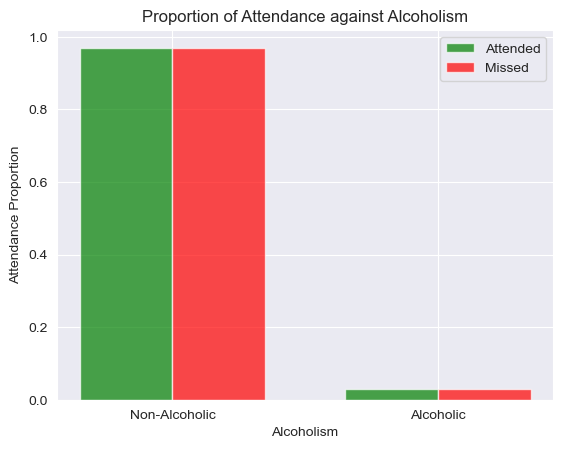

```python
#Use proportion function to see proportion of attendance against gender

x_col = 'Alcoholism'
alcoholism_proportions = var_proportion(df, labels, x_col)
```

**Answer:**

- Patients don't who take alcohol and attended their appointments seem to have almost the same proportion as those that missed appointments so this feature doesn't appear to impact attendance

### Research Question 9: Does a patient's pre-existing condition impact the likelihood of them showing up for an appointment?

###### Hypertension

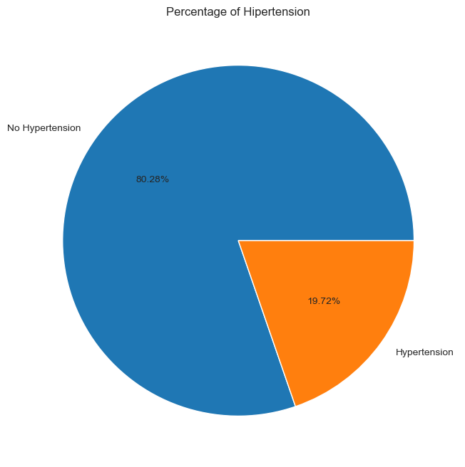

```python
labels = ['No Hypertension', 'Hypertension']
var_pie_label('Hipertension', labels)
```

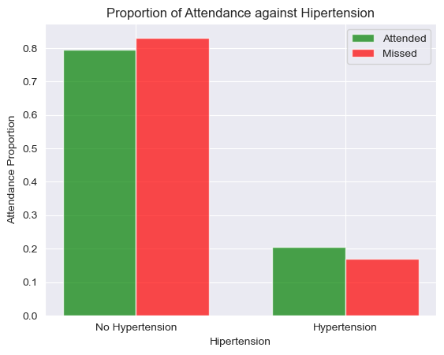

```python
x_col = 'Hipertension'
hypertension_proportions = var_proportion(df, labels, x_col)
```

###### Diabetes

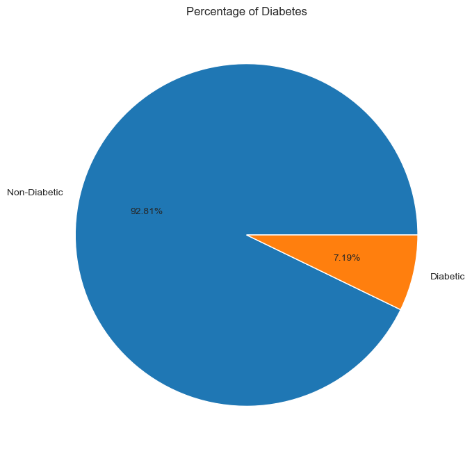

```python
labels = ['Non-Diabetic', 'Diabetic']
var_pie_label('Diabetes', labels)
```

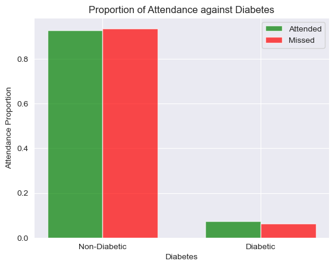

```python
x_col = 'Diabetes'
hypertension_proportions = var_proportion(df, labels, x_col)
```

###### Handicap

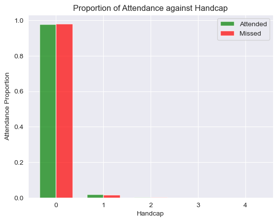

```python
labels = [0,1,2,3,4]
x_col = 'Handcap'
hypertension_proportions = var_proportion(df, labels, x_col)
```

**Answer:**

- From the analysis above, patients with pre-existing conditions tend to show up/miss appointments just as those that dont have pre-existing conditions.

### Research Question 10: Do patients tend to show up more on specific days of the week?

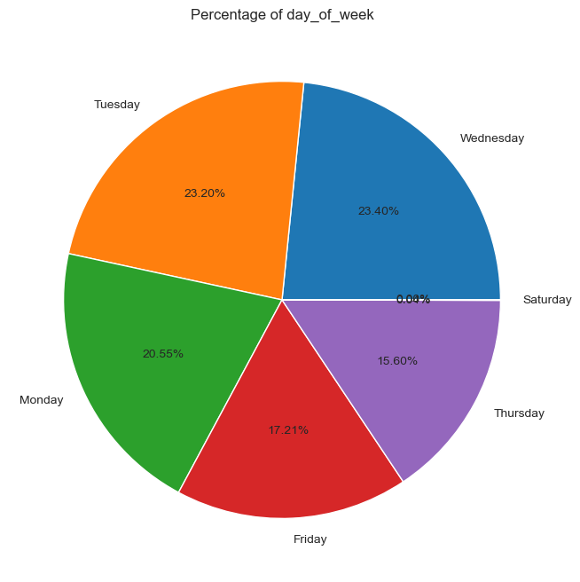

```python
# First identify distribution of day of week with a pie chart
var_pie('day_of_week')
```

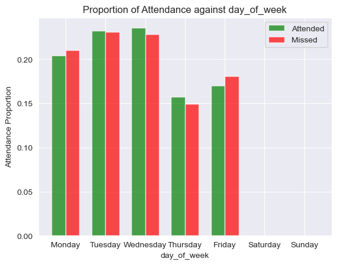

```python
#Use proportion function to see proportion of attendance against gender

labels = ['Monday','Tuesday','Wednesday','Thursday','Friday','Saturday','Sunday']
x_col = 'day_of_week'
dow_proportions = var_proportion(df, labels, x_col)
```

**Answer:**

- There's no correlation between the day of week and probability of patients making an appearance for their appointments.

### Research Question 11: Do longer waiting times have lower turn up rates?

```python
#For this we'll use the df_wait dataset where we eliminated entries where wait time < 0
df_wait.columns
```

```
Index(['Gender', 'ScheduledDay', 'AppointmentDay', 'Age', 'Neighbourhood',
       'Scholarship', 'Hipertension', 'Diabetes', 'Alcoholism', 'Handcap',
       'SMS_received', 'No-show', 'age_group', 'day_of_week', 'wait_days'],
      dtype='object')
```

```
Min wait_days:0
Max wait_days:178
Average wait_days:14.64
```

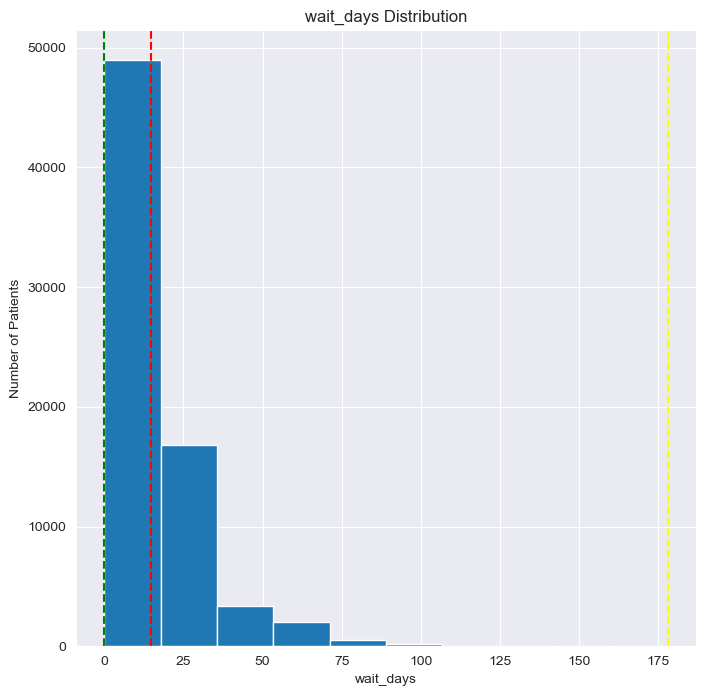

```python
# Use histogram function to view distribution of wait_days
cont_hist(df_wait,'wait_days')
```

```python
#Get separate dataset where patients attended and those that missed their appointments
df_show = df_wait[df_wait['No-show'] == 'Attended']
df_noshow = df_wait[df_wait['No-show'] == 'Missed']
```

```
Min wait_days:0
Max wait_days:178
Average wait_days:14.01
```

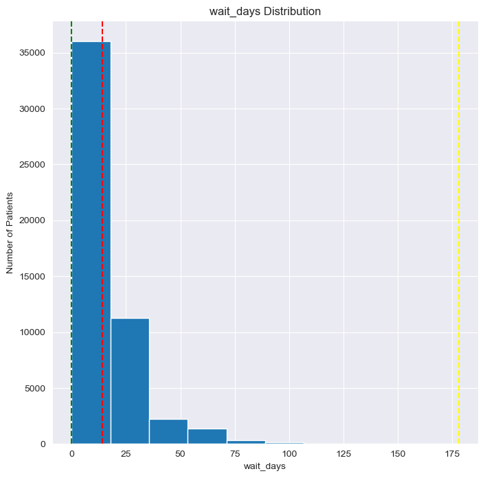

```python
# Use histogram function to view distribution of attended appointments
cont_hist(df_show,'wait_days')
```

```
Min wait_days:0
Max wait_days:178
Average wait_days:16.22
```

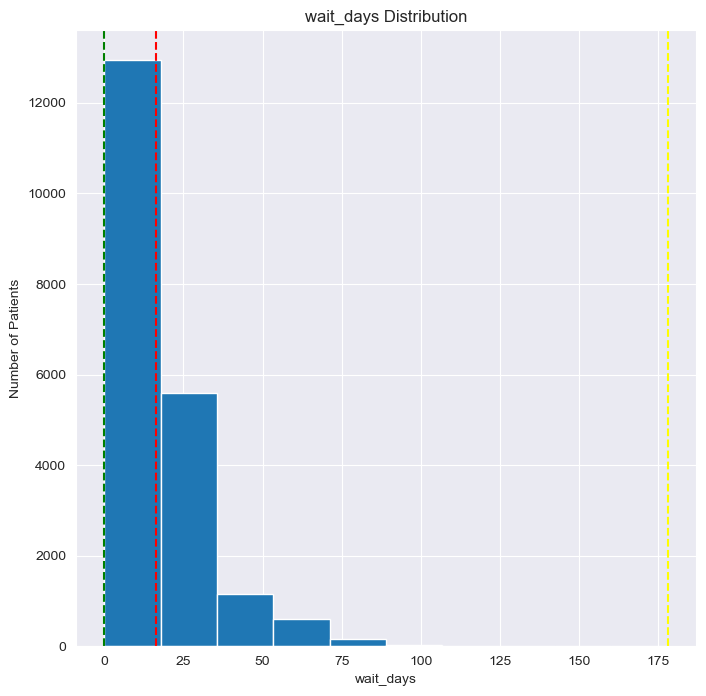

```python
# Use histogram function to view distribution of missed appointments
cont_hist(df_noshow,'wait_days')
```

**Answer:**

- The distribution of wait days on the attended dataframe is similar to that of patients that missed their appointments. It is skewed to the right. Patients tend to miss longer wait time as much as they attend them.

### Research Question 12: Do same day appointments have a higher turn out?

```python
#Get subset of data where patients had their appointment the same day they called
df_sameday = df[df.wait_days == 0]
df_sameday.head()
```

|  | Gender | ScheduledDay | AppointmentDay | Age | Neighbourhood | Scholarship | Hipertension | Diabetes | Alcoholism | Handcap | SMS_received | No-show | age_group | day_of_week | wait_days |
| --- | --- | --- | --- | --- | --- | --- | --- | --- | --- | --- | --- | --- | --- | --- | --- |
| 12 | F | 2016-04-28 11:33:51+00:00 | 2016-04-29 00:00:00+00:00 | 22 | NOVA PALESTINA | 1 | 0 | 0 | 0 | 0 | 0 | Attended | Young Adult | Friday | 0 |
| 13 | M | 2016-04-28 14:52:07+00:00 | 2016-04-29 00:00:00+00:00 | 28 | NOVA PALESTINA | 0 | 0 | 0 | 0 | 0 | 0 | Attended | Adult | Friday | 0 |
| 14 | F | 2016-04-28 10:06:24+00:00 | 2016-04-29 00:00:00+00:00 | 54 | NOVA PALESTINA | 0 | 0 | 0 | 0 | 0 | 0 | Attended | Adult | Friday | 0 |
| 16 | M | 2016-04-28 08:51:47+00:00 | 2016-04-29 00:00:00+00:00 | 50 | NOVA PALESTINA | 0 | 0 | 0 | 0 | 0 | 0 | Attended | Adult | Friday | 0 |
| 17 | F | 2016-04-28 09:28:57+00:00 | 2016-04-29 00:00:00+00:00 | 40 | CONQUISTA | 1 | 0 | 0 | 0 | 0 | 0 | Missed | Adult | Friday | 0 |

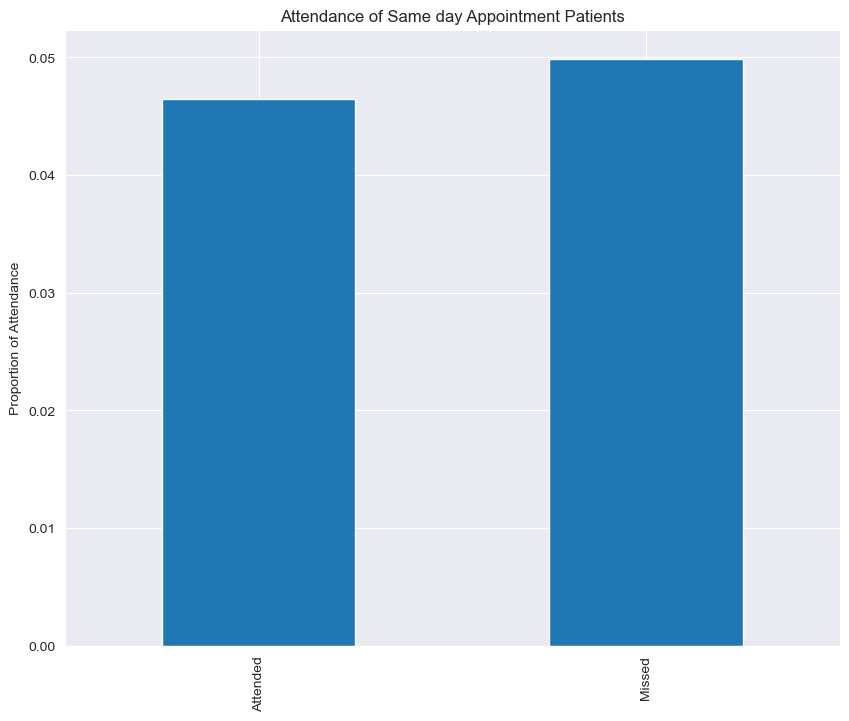

```python
# Plot to see what proportion of patients showed up to their same day appointment
(df_sameday['No-show'].value_counts()/ (df.groupby('No-show').count()['ScheduledDay'])).plot(kind = 'bar', figsize = (10,8))
plt.title('Attendance of Same day Appointment Patients')
plt.ylabel('Proportion of Attendance')
```

## Conclusions

### Research Question 1: What are the statistic attributes of our categorical columns?

**Observation:**

- **Gender**: We have more female patients than males
- **Neighborhood**: We have 81 neighborhoods, with most patients coming from **JARDIM CAMBURI**
- **Scholarship**: Most patients do not have a scholarship
- **Hypertension**: Most patients do not have hypertension
- **Diabetes**: Most patients do not have a diabetes
- **Alcohol**: Most patients do not take alcohol
- **Handicap**: We have 5 different handicap categories; With 0 meaning no handicap, ,ost patients are not handicapped
- **SMS-Received**: Most patients did not reminders for their appointments via text
- **Day of Week**: Most appointments are set for Wednesday, and the dataset has appointments for 6 days of the week

### Research Question 2: From the dataset, what percentage of patients missed their appointments?

**Answer:**

- 20% of patients missed their appointments.

### Research Question 3: What is the age distribution of patients?

**Answer:**

- Age distribution is skewed to the right. The minimum age is 0, maximum age is 115 and the average age is approximately 37 years.

### Research Question 4: Does age have a relationship with probability of patients showing up?

**Observation:**

- Adults form the largest section of the dataset(However, they form the largest bin) as 41.43% of the entire dataset.

**Answer:**

- Patients in the Child, Young Adult and Adult categories seem to have a higher missing rate. For Mature Adults and the Elderly, they're more likely to show up for appointments.

### Research Question 5: Do patients with Scholarship tend to show up more?

**Observation:**

- Only 9.83% of our sample dataset have received a scholarship.

### Research Question 6: Is a certain gender associated with a higher attendance rate?

**Observation:**

- Females form the majority of the sample dataset, as 65% of the entire dataset

**Answer:**

- The sample has more females than males. When it comes to attendance, the proportions of thse who missed to those who attended does not have a large variance so there exists no relationship between gender and probability of attendandce.

### Research Question 7: Do patients that receive a text tend to show up more?

**Observation:**

- Only 32% of our dataset has received text reminders of their appointment.

### Research Question 8: Is there any relationship between alcoholism of patients and their and showing up for appointments?

**Observation:**

- Only 3% of our patients in our sample dataset take alcohol.

**Answer:**

- Patients don't who take alcohol and attended their appointments seem to have almost the same proportion as those that missed appointments so this feature doesn't appear to impact attendance

### Research Question 9: Does a patient's pre-existing condition impact the likelihood of them showing up for an appointment

**Answer:**

- From the analysis above, patients with pre-existing conditions tend to show up/miss appointments just as those that dont have pre-existing conditions.?

### Research Question 10: Do patients tend to show up more on specific days of the week?

**Answer:**

- There's no correlation between the day of week and probability of patients making an appearance for their appointments.

### Research Question 11: Do longer waiting times have lower turn up rates?

**Answer:**

- The distribution of wait days on the attended dataframe is similar to that of patients that missed their appointments. It is skewed to the right. Patients tend to miss longer wait time as much as they attend them.

### References:

1. [Order by day of week](https://technology.amis.nl/data-analytics/ordering-rows-in-pandas-data-frame-and-bars-in-plotly-bar-chart-by-day-of-the-week-or-any-other-user-defined-order/)
2. [Brazil Age](https://www.indexmundi.com/brazil/age_structure.html)
3. [Format String](https://stackoverflow.com/questions/1225637/inserting-the-same-value-multiple-times-when-formatting-a-string)